# Multiscale Spatial Error Assessment

Nick Malleson

03 June, 2016 (11:48)

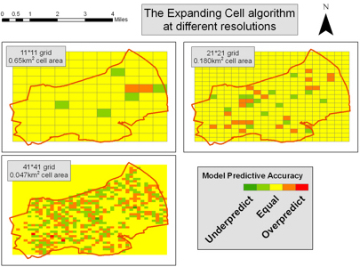

# Multiscale Spatial Error Assessment

This is the R implementation of the Multiscale Spatial Error Assessment method (aka [Multiscale Validation](http://www.geog.leeds.ac.uk/courses/other/programming/practicals/general/modelling/validation/multiscale-code/2.html)).

The aim of the method is to take two point-patterns, iteratively aggregate the points to cells of increasing size, and calculate the error between the two data sets at the different grid resoultions. See the right images for an example (from [here](http://www.geog.leeds.ac.uk/courses/other/programming/practicals/general/modelling/validation/multiscale-code/2.html)).

Ultimately the method will be converted into a (suite of) function(s) and integrated with the Andresen’s S index.

The method has has been used in the following paper:

Malleson, N., A. Heppenstall, L. See, A. Evans (2013) Using an agent-based crime simulation to predict the effects of urban regeneration on individual household burglary risk. *Environment and Planning B: Planning and Design.* 40(3) 405-426. Available [here](http://www.envplan.com/abstract.cgi?id=b38057) and [here](http://nickmalleson.co.uk/wp-content/uploads/2013/05/EPB-V6-forBlog.pdf) (if you don’t have access to the journal)

Thanks to Lex Comber and Chris Brunsdon for their excellent book ‘R for Spatial Analysis and Mapping’. I got most of the R GIS stuff from there.

Brunsdon, C and Comber, L (2015) *An Introduction to R for Spatial Anaysis and Mapping*. Sage

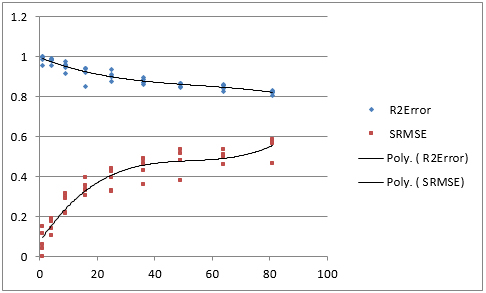

## Configuration

Configure the script here. (Un)comment or edit lines as appropriate to change the data used and the parameters for the method.

```r
N <- 10 # The number of cell resolutions to run. (1=just one big cell surrounding all of the data)

# For the basic test:
#datasource <- "../data/basic_test/" # The folder with the shapefiles

# Some London data:
#datasource <- "../data/london_burglary/"

# Some Vancouver data:
datasource <- "../data/vancouver_all/"

base.layer <- "points1" # THe name of the base dataset
test.layer <- "points2" # THe name of the test dataset
#areas.layer <- "areas"  # The polygon boundary file

# multiprocess <- FALSE # Whether to run the simulation using multiple cores
```

## Read Data

```r
# Read some data

#areas <- readOGR(ds = datasource, layer=areas.layer)
base.data <- readOGR(ds = datasource, layer=base.layer)
test.data <- readOGR(ds = datasource, layer=test.layer)
```

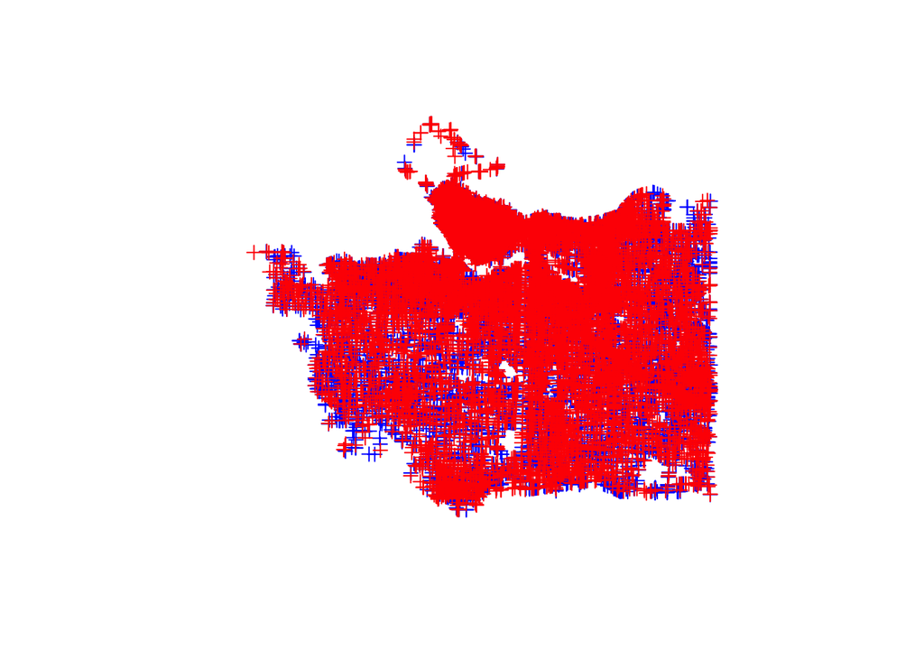

```r
#plot(areas)
plot(base.data, col="blue")
plot(test.data, col="red",add=T)
```

## The Multi-Scale Error Assessment Method (MSEA)

### Define the MSEA

The following defines a function that will run the method.

```r
#' Multi-Scale Error Assessment (MSEA).
#'
#' Run the Multi-Scale Error Assessment (MSEA) method, returning the difference between two point data sets at different geographical scales using different measures of error
#'
#' XXXX OTHER DETAILS (i.e. how the method works?)
#'
#' @param points1 A set of points (a SpatialPointsDataFrame)
#' @param points2 The set of points to compare against (another SpatialPointsDataFrame)
#' @param N The number of times to sub-divide the largest cell. I.e. if N=20 then the smallest grid at which error is calculated will be 20*20 cells.
#'
#' @return An list that encapsulates the results of the test as well as some other useful information:
#'
#'  results - a list of the individual grids computed for each cell size. This will have length N. Each item in the list is a SpatialPolygonsDataFrame with the following attributes:
#'  \itemize{
#'  \item{"CellID"}{A unique numerical ID for each cell in the grid}
#'  \item{"points1"}{The number of points from the points1 dataset that fall within the cell}
#'  \item{"points2"}{The number of points from the points2 dataset that fall within the cell}
#'  \item{"p1.pct"}{The percentage of points from the points1 dataset that fall within the cell}
#'  \item{"p2.pct"}{The percentage of points from the points1 dataset that fall within the cell}
#'  \item{"diff"}{The difference in the number of points (points1 - points2)}
#'  \item{"abs.diff"}{The absolute difference in the number of points}
#'  \item{"abs.pct.diff"}{The absolute difference in the percentages (nice to map)}
#' }
#'
#'  cell.areas - A vector (length N) with the square area of a cell in each grid
#'
#'  num.cells - A vector (length N) with the number of cells in each grid
#'
#'  rss - a vector of length N with the residual sum of squares error value for each grid
#'
#'  r.squared - a vector of length N with the R-Squared error for each grid
#'
#'  rmse - a vector of length N with the Root Mean Square Error value for each grid
#
#' @examples
#' rmse(points1, points2)
msea <- function(points1, points2, N=20) {

  # Check that the projections are the same
  if ( proj4string(points1) != proj4string(points2) ) {
    warning("The points1 and points2 projections are different, this will probably lead to catastrophic results!")
  }

  bb <- bbox(points1 + points1) # A bounding box around all points

  # Store all grids (data frames) in a big long list
  results <- list()
  # Also remember some other things that are useful later
  cell.areas <- c() # The area of the cells
  num.cells <- c()  # The number of cells in each iteration

  # Create the grids - adapted from Brunsdon & Comber (2015, p150)
  for (i in seq(1,N)) {
    # Cell size is the total width divided by the number of cells to draw so far (i)
    cell.width <- (bb[1,2] - bb[1,1]) / i
    cell.height <- (bb[2,2] - bb[2,1]) / i
    cell.areas <- c(cell.areas, (cell.width * cell.height) ) # Also remember the cell area for later

    # For each resolution, repeat a few times by slightly shifting each grid in N, E, S, W to lessen the impact of MAUP
    # NOT IMPLEMENTED YET. SLIGHTLY TRICKY BECAUSE GRID WILL NEED TO BE BIGGER OTHERWISE SOME POINTS WILL NOT BE COVERED
    for (shift in 1:1) {
      # Need to calculate the centre of the bottom-right cell
      if (shift==1) { # This is the grid with no shifting (i.e. it fits perfectly over the study area)
        centre.x <- bb[1,1] + ( cell.width / 2 )
        centre.y <- bb[2,1] + ( cell.height / 2 )
      }
      # .. WILL IMPLEMENT REMAINING SHIFTS HERE

      # Create a grid
      grd <- GridTopology(
        cellcentre.offset = c(centre.x, centre.y), # No offset, the grid will just cover all the points
        cellsize = c(cell.width, cell.height),
        cells.dim = c(i,i)
      )

      number.of.cells <- i * i
      num.cells <- c(num.cells, number.of.cells) # Remember the number of cells in this iteration

      # Convert the grid into a SpatialPolygonsDataFrame
      spdf <- SpatialPolygonsDataFrame(
        as.SpatialPolygons.GridTopology(grd),
        data = data.frame(c(1:number.of.cells)),
        match.ID = FALSE
      )
      proj4string(spdf) <- proj4string(points1)
      names(spdf) <- "CellID" # Name the column

      # Aggregat the points
      spdf@data$points1 <- poly.counts(points1, spdf)
      spdf@data$points2 <- poly.counts(points2, spdf)

      # Calculate percentages of points in each area (might be useful)
      spdf@data$p1.pct <- 100 * spdf@data$points1 / sum(spdf@data$points1 )
      spdf@data$p2.pct <- 100 * spdf@data$points2 / sum(spdf@data$points2 )

      # Calculate the errors

      # Difference in the number of points
      spdf@data$diff <- spdf@data$points1 - spdf@data$points2
      # Absolute difference
      spdf@data$abs.diff <- abs(spdf@data$points1 - spdf@data$points2)

      # Absolute Difference in percentages
      spdf@data$abs.pct.diff <- abs(spdf@data$p1.pct - spdf@data$p2.pct)

      # Store this result
      results[[i]] <- spdf

    } # for shifting grids (not currently used)

  } # for cell sizes

  # Now calculte the errors
  rss <- c() # Residual sum of squares
  r.squared <- c()
  rmse <- c()


  for (i in 1:length(results)) {

    the.result <- results[[i]]@data # Convenience for referring to the current result we're looking at
    #the.result.nozero <- results[[i]]@data # Convenience for referring to the current result we're looking at

    # RSS
    rss <- c(rss, sum( ( the.result$points1 - the.result$points2 )**2 ))
    # R squared
    r.squared <- c(r.squared, summary(lm(the.result$points1 ~ the.result$points2, data=the.result))$r.squared )
    # RMSE
    rmse <- c(rmse, rmse(the.result$points1, the.result$points2) )

  }

  # Return the results
  r <- list(
    "results" = results,
    "cell.areas" =cell.areas,
    "num.cells" = num.cells,
    "rss" = rss,
    "r.squared" = r.squared,
    "rmse" = rmse
  )
  return(r)

} # function
```

Now run the function

```r
r <- msea(base.data, test.data)
```

## Map the results

For a sanity check: map the total number of base and test points for some different grids

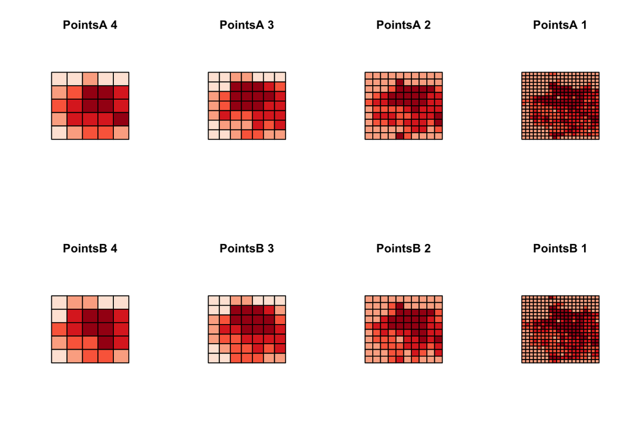

```r
par(mfrow=c(2,4))

#plot(results[[length(results)]])
#points(base.data)
for (i in 4:1) {
  index <- round(length(r$results) / i )
  choropleth(r$results[[index]], r$results[[index]]@data$points1, main=paste("PointsA",i))
}

#plot(results[[length(results)]])
#points(test.data)
for (i in 4:1) {
  index <- round(length(r$results) / i )
  choropleth(r$results[[index]], r$results[[index]]@data$points2, main=paste("PointsB",i))
}
```

# Now map the difference in the proportions

```r
par(mfrow=c(2,2))
for (i in 4:1) {
  index <- round(length(r$results) / i )
  choropleth(r$results[[index]], r$results[[index]]@data$abs.pct.diff, main=paste("Absoulte difference in percentages",i))
}
```

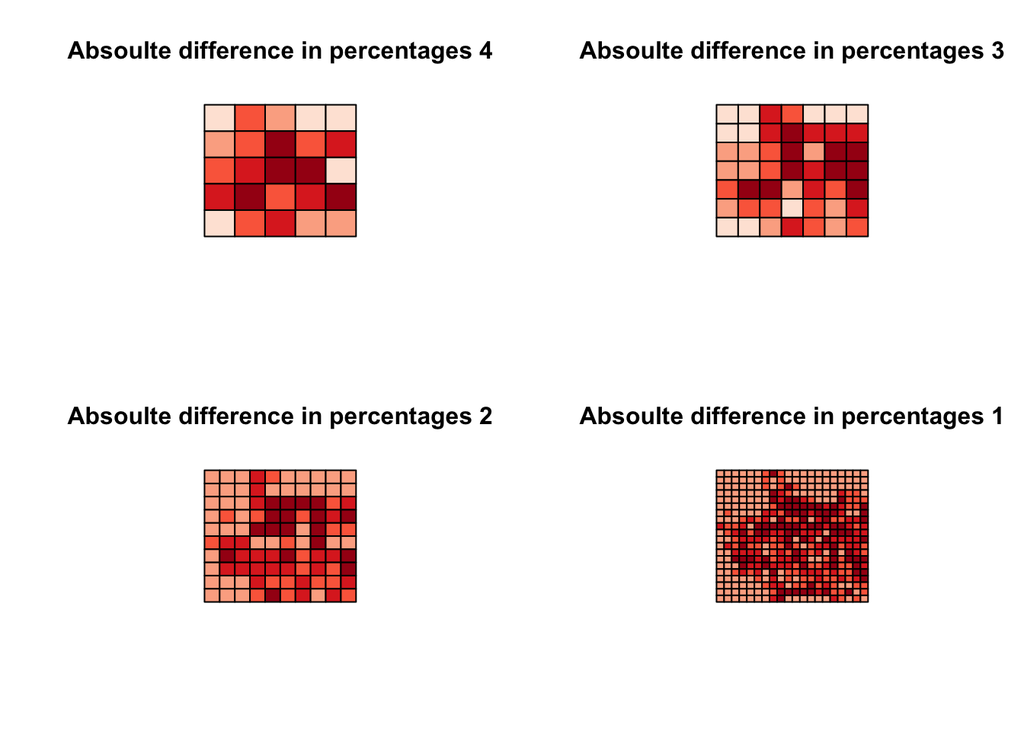

Finally make a fuzzy grid of all results

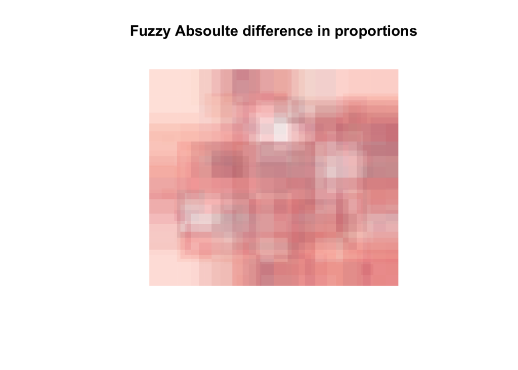

```r
par(mfrow=c(1,1))

statistic <- "abs.prop.diff" # The statistic to map
last.result <- r$results[[length(r$results)]] # Convenience for list result generated (the smallest grid)

# Shading
shades <- shading(
    classIntervals(last.result@data$abs.pct.diff, n = 8, style = 'kmeans')$brks,
    cols=add.alpha(brewer.pal(9,'Reds'), (1/N))
)

choropleth(
  last.result, last.result@data$abs.pct.diff,
  shading = shades,
  main="Fuzzy Absoulte difference in proportions",
  lty=0
  )

for ( index in 1:(N-1)) {
  choropleth( r$results[[index]], r$results[[index]]@data$abs.pct.diff,
  shading = shades,
  lty=0,
  add=TRUE)
}
```

## Calculate and graph the errors

Calculate the following errors:

- **Residual Sum of Squares (RSS)** (This is easy, just add up the square of the differences)
- **R-Squared**
- **Root Mean Square Error (RMSE)**

And then graph them using two difference x axes:

- The number of cells used
- The square area of an individual cell (smallest cells first)

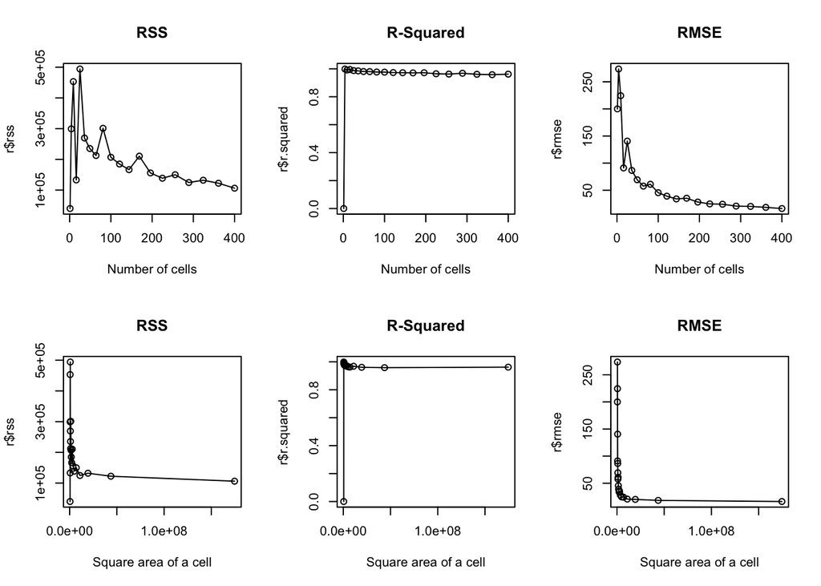

```r
# Go through all of the results and calculate errors

par(mfrow=c(2,3))

plot(x=r$num.cells, y=r$rss, type='o', main="RSS", xlab="Number of cells")
plot(x=r$num.cells, y=r$r.squared, type='o', main="R-Squared", xlab="Number of cells")
plot(x=r$num.cells, y=r$rmse, type='o', main="RMSE", xlab="Number of cells")
plot(x=rev(r$cell.areas), y=r$rss, type='o', main="RSS", xlab="Square area of a cell")
plot(x=rev(r$cell.areas), y=r$r.squared, type='o', main="R-Squared", xlab="Square area of a cell")
plot(x=rev(r$cell.areas), y=r$rmse, type='o', main="RMSE", xlab="Square area of a cell")
```